### Autores

| Nome | Registro Acadêmico |
| --- | --- |
| **Carlos Augusto Jardim Chiarelli** | 165685 |
| **Rodrigo Makoto Takumi** | 176897 |

# 04 – **Diagrama de blocos**

Este trabalho foi desenvolvido em linguagem **"Python 3.7"**.

```python
# bibliotecas
import numpy as np
import sympy as sp
import matplotlib.pyplot       as plt
from   scipy.signal            import lsim, lti, step, impulse
from   IPython.core.pylabtools import figsize
from   IPython.display         import Image

figsize(12, 8)                         # tamanho gráficos
plt.rcParams.update({'font.size': 14}) # tamanho da fonte
sp.init_printing()                     # printar variáveis simbólicas
```

## Exercício 1

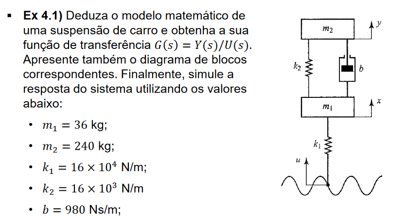

```python
Image('../dados/imagens/04_exe_1.png')
```

Iniciando com o DCL do sistema (análise na vertical) em $m_{1}$ e partindo de algumas considerações:

$$ $$$$ \begin{cases} u > x \\ x < y \\ \dot{x} < \dot{y} \end{cases} $$$$ $$

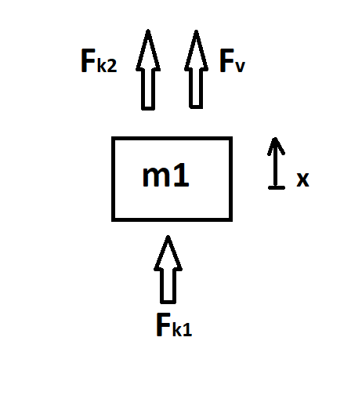

```python
Image('../dados/imagens/04_exe_1_1.png')
```

$$ $$$$\sum F_{x} = m_{1}\ddot{x}$$$$ $$$$ m_{1}\ddot{x} = k_{2}(y-x) + b(\dot{y}-\dot{x}) + k_{1}(u-x) $$$$ $$

Isolando as variáveis $x$ e $y$ temos:

$$ $$$$ m_{1}\ddot{x} + b\dot{x} + (k_{1}+k_{2})x = b\dot{y} + k_{2}y + k_{1}u $$

Aplicando o operador de Laplace na equação:

$$ $$$$ [m_{1}s^2 + bs + (k_{1}+k_{2})]X(s) = [bs + k_{2}]Y(s) + k_{1}U(s) $$$$ $$

Agrupando os termos chegamos em:

$$ A(s)X(s) = B(s)Y(s) + C(s)U(s) $$$$ $$$$ Y(s) = \frac{A(s)}{B(s)}X(s) - \frac{C(s)}{B(s)}U(s) \tag{1}\label{eq:1}$$

Resolvendo o DCL para $m_{2}$ temos:

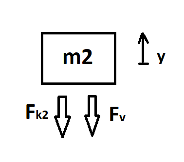

```python
Image('../dados/imagens/04_exe_1_2.png')
```

$$ $$$$\sum F_{y} = m_{2}\ddot{y}$$$$ $$$$ m_{2}\ddot{y} = -k_{2}(y-x) - b(\dot{y}-\dot{x})$$$$ $$$$ m_{2}\ddot{y} + b\dot{y} + k_{2}y = b\dot{x} + k_{2}x $$

Agrupando os termos chegamos em:

$$ D(s)Y(s) = E(s)X(s) $$$$ $$$$ X(s) = \frac{D(s)}{E(s)}Y(s) \tag{2}\label{eq:2}$$$$ $$

Substituindo **(2)** em **(1)**:

$$ $$$$ Y(s) = \frac{A(s)}{B(s)} \left[\frac{D(s)}{E(s)}Y(s) \right] - \frac{C(s)}{B(s)}U(s) $$$$ $$

Então obtemos a função de transferência do sistema:

$$ $$$$ G(s) = \frac{Y(s)}{U(s)} = \frac{C(s)E(s)}{A(s)D(s)-B(s)E(s)} $$

$$ $$

```python
# manipulação simbólica (álgebra)
sp.init_printing()

# setando variaveis
m1, m2, k1, k2, b, s = sp.symbols('m1, m2, k1, k2, b, s')

A = m1*s**2 + b*s + k1 + k2
B = b*s + k2
C = k1
D = m2*s**2 + b*s + k2
E = b*s + k2

Gs = C*E/(A*D - B*E)

sp.factor(Gs, s, b)
```

$\displaystyle \frac{k_{1} \left(b s + k_{2}\right)}{b k_{1} s + b s^{3} \left(m_{1} + m_{2}\right) + k_{1} k_{2} + m_{1} m_{2} s^{4} + s^{2} \left(k_{1} m_{2} + k_{2} m_{1} + k_{2} m_{2}\right)}$

$$ $$

Substituindo as variáveis intermediárias:

$$ $$$$ \frac{Y(s)}{U(s)} = \frac{k_{1}(bs+k_{2})}{m_{1}m_{2}s^4 + (m_{1}+m_{2})bs^3 + [k_{1}m_{2}+(m_{1}+m_{2})k_{2}]s^2 + k_{1}bs + k_{1}k_{2}} $$$$ $$

Construindo o diagrama de bloco a partir de **(2)** e **(1)** temos:

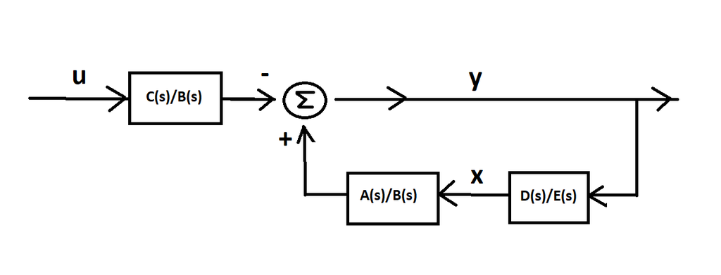

```python
Image('../dados/imagens/04_exe_1_3.png')
```

```python
# vetor de tempo
dt = 1e-3
t  = np.arange(0, 3.5, dt) # tempo (0 a 1s)

# propriedades do sistema
m1, m2 = 36  , 240
k1, k2 = 16e4, 16e3
b      = 980

# função transferencia
Num = [k1*b, k1*k2]        # [s^1, s^0]

Den = [m1*m2,              # s^4
       (m1+m2)*b,          # s^3
       k1*m2 + (m1+m2)*k2, # s^2
       k1*b,               # s^1
       k1*k2]              # s^0

Gs = (Num, Den) # TF
```

```python
LTI = lti(Num, Den)        # gerando o Sistema

t_step, y_step = step(LTI, T=t) # resposta ao impulso

u = np.ones(len(t))        # u(t) = 1 para t>0
```

```python
def plotaResposta(t, saida, entrada, titulo):
    # visulizando resposta
    plt.plot(t, saida,   label='y(t)', color='r')
    plt.plot(t, entrada, label='u(t)', color='b')

    plt.title(titulo+' \n')
    plt.xlabel('\n Tempo (s)')
    plt.ylabel('Deslocamento (m) \n')
    plt.legend(loc="upper right", framealpha=1)
    plt.grid(color = 'b', alpha = 0.5, linestyle = 'dashed', linewidth = 0.5)
    plt.show()
```

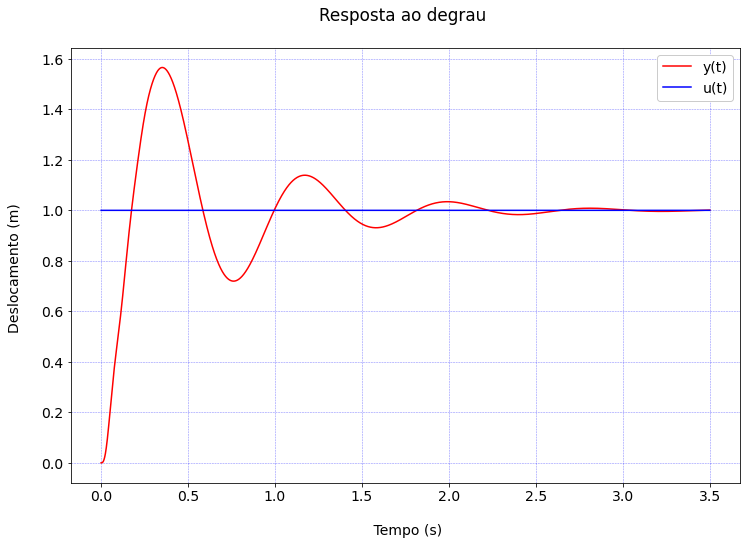

```python
plotaResposta(t_step, y_step, u, 'Resposta ao degrau')
```

```python
t_sin  = np.arange(0, 6, dt) # tempo (0 a 1s)

f = 0.5 # Hz
A = 0.5 # amplitude [m]

u_senoidal  = A * np.sin(2*np.pi*f*t_sin)     # entrada senoidal

t_sin, y_sin, x_out = lsim(Gs, u_senoidal, t_sin) # simulacao
```

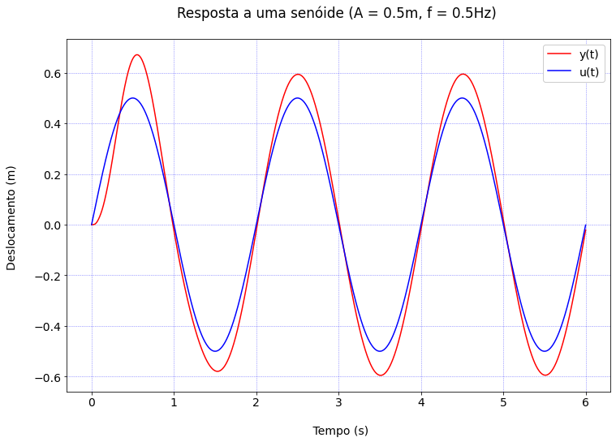

```python
plotaResposta(t_sin, y_sin, u_senoidal, 'Resposta a uma senóide (A = 0.5m, f = 0.5Hz)')
```

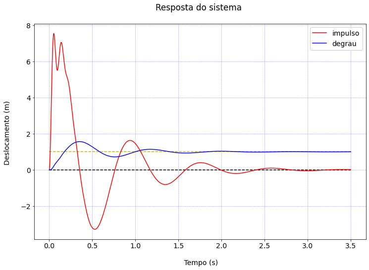

```python
t_imp, y_imp = impulse(LTI, T=t)  # resposta ao impulso

plt.hlines(1,0,3.5, colors='y',linestyles='dashed')
plt.hlines(0,0,3.5, colors='black',linestyles='dashed')

plt.plot(t_imp, y_imp,   label='impulso', color='r')
plt.plot(t_step, y_step, label='degrau', color='b')

plt.title('Resposta do sistema \n')
plt.xlabel('\n Tempo (s)')
plt.ylabel('Deslocamento (m) \n')
plt.legend(loc="upper right", framealpha=1)
plt.grid(color = 'b', alpha = 0.5, linestyle = 'dashed', linewidth = 0.5)
plt.show()
```

## Exercício 2

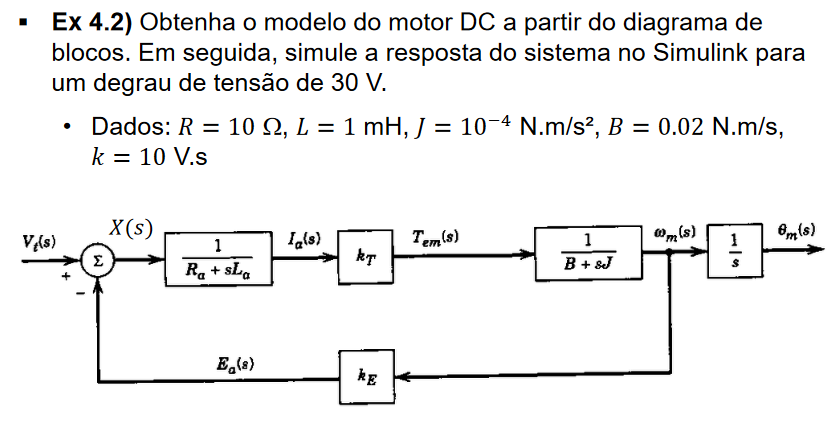

```python
Image('../dados/imagens/04_exe_2.png')
```

Obtendo as relações de cada módulo do sistema no domínio de Laplace e segmentando os blocos de funções de transferência ($F(s)$) e ganhos ($constante$) :

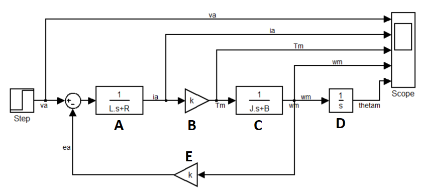

```python
Image('../dados/imagens/04_exe_2_1.png')
```

- Circuito da armadura:

$$ $$$$ X(s) = V_{t}(s) - E_{a}(s) $$$$ $$$$ I_{a}(s) = \frac{1}{R + sL}X(s) $$$$ $$$$ I_{a}(s) = \frac{1}{R + sL}\left[V_{t}(s) - E_{a}(s) \right] $$$$ $$$$ I_{a}(s) = A(s)\left[V_{t}(s) - E_{a}(s) \right] \tag{1}\label{eq:3} $$$$ $$

- Lei da força de Lorentz:

$$ $$$$ T_{m}(s) = kI_{a}(s) $$$$ $$$$ T_{m}(s) = BI_{a}(s) \tag{2}\label{eq:4} $$$$ $$

- Eixo do motor:

$$ $$$$ \omega_{m}(s) = \frac{1}{[sJ + B]}T_{m}(s) $$$$ $$$$ \omega_{m}(s) = C(s)T_{m}(s) \tag{3}\label{eq:5}$$$$ $$

- Posição angular:

$$ \theta_{m}(s) = \frac{1}{s}\omega_{m}(s)$$$$ $$$$ \theta_{m}(s) = D(s)\omega_{m}(s) \tag{4}\label{eq:6}$$$$ $$

- Lei de Faraday de indução:

$$ $$$$ E_{a} = k\omega_{m}(s) $$$$ $$$$ E_{a} = E\omega_{m}(s) \tag{5}\label{eq:7}$$$$ $$

Agora vamos encontrar a função de transferência do sistema com manipulação simbólica:

$$ $$$$ G(s) = \frac{\theta_{m}(s)}{V_{t}(s)} $$$$ $$

Substituindo **(2)** em **(3)**, seguido desta gerada substituída em **(4)**:

$$ $$$$ \theta(s) = D(s)C(s)BI(s) $$

$$ $$$$ I(s) = \frac{\theta(s)}{D(s)C(s)B} \tag{6}\label{eq:9}$$

$$ $$

Substituindo **(4)** em **(5)**:

$$ E_{a} = \frac{E}{D(s)}\theta(s) \tag{7}\label{eq:10}$$

Substtituindo **(6)** e **(7)** em **(1)**:

$$ $$

$$ \frac{\theta}{BCD} = A\left(V - \frac{E}{D}\theta \right) $$$$ $$$$ \theta \left(\frac{1}{ABCD}+\frac{E}{D} \right) = V $$$$ $$$$ \frac{\theta_{m}(s)}{V_{t}(s)} = \frac{1}{\left(\frac{1}{ABCD}+\frac{E}{D} \right)} $$$$ $$$$ G(s) = \frac{1}{\left(\frac{1}{A(s)BC(s)D(s)}+\frac{E}{D(s)} \right)} $$$$ $$

De forma análoga poderíamos isolar $\omega_{m}$ e chegar na seguinte função de transferência para essa variável:

$$ $$$$ F(s) = \frac{\omega(s)}{V(s)} $$$$ $$$$ F(s) = \frac{1}{\left(\frac{1}{A(s)BC(s)} + E \right)} $$$$ $$

Seguindo o mesmo raciocínio com intuito de monitorar $i(t)$ e $T_{m}(t)$:

$i(t)$:

$$ $$$$ M(s) = \frac{I(s)}{V(s)} $$$$ $$$$ M(s) = \frac{1}{\left(EC(s)B + \frac{1}{A(s)} \right)} $$$$ $$

$T_{m}(t)$:

$$ $$$$ O(s) = \frac{T_{m}(s)}{V(s)} $$$$ $$$$ O(s) = \frac{B}{\left(EC(s)B + \frac{1}{A(s)} \right)} $$$$ $$

```python
# manipulação simbólica (álgebra)
k, L, J, B_cte, R, s = sp.symbols('k, L, J, B_cte, R, s') # variáveis

A = 1/(L*s+R)
B = k
C = 1/(J*s+B_cte)
D = 1/s
E = k
```

Vamos calcular as funções transferências multiplicando os polinômios simbolicamente.

Obtendo essas relações conseguimos enxergar separadamente as variáveis do sistema.

```python
Gs = 1/(1/(A*B*C*D) + E/D) # gerando G(s)

print('G(s) é igual a \n')

sp.factor(Gs, s)           # fatorando G(s) em s
```

```
G(s) é igual a
```

$\displaystyle \frac{k}{s \left(B_{cte} R + J L s^{2} + k^{2} + s \left(B_{cte} L + J R\right)\right)}$

```python
Fs = 1/(1/(A*B*C) + E) # gerando F(s)

print('F(s) é igual a \n')

sp.factor(Fs, s)       # fatorando F(s) em s
```

```
F(s) é igual a
```

$\displaystyle \frac{k}{B_{cte} R + J L s^{2} + k^{2} + s \left(B_{cte} L + J R\right)}$

```python
Ms = 1/(E*C*B + 1/A) # gerando M(s)

print('M(s) é igual a \n')

sp.factor(Ms, s)     # fatorando M(s) em s
```

```
M(s) é igual a
```

$\displaystyle \frac{B_{cte} + J s}{B_{cte} R + J L s^{2} + k^{2} + s \left(B_{cte} L + J R\right)}$

```python
Os = Ms * B # gerando O(s)

print('O(s) é igual a \n')

sp.factor(Os, s)     # fatorando O(s) em s
```

```
O(s) é igual a
```

$\displaystyle \frac{k \left(B_{cte} + J s\right)}{B_{cte} R + J L s^{2} + k^{2} + s \left(B_{cte} L + J R\right)}$

Iremos gerar a entrada de tensão (degrau) de 30V da seguinte forma:

$$ $$$$ \begin{cases} V_{a}(t < 0.1) = 0 \\ V_{a}(t >= 0.1) = 30 \end{cases} $$$$ $$

```python
# vetor de tempo
dt = 1e-3
t  = np.arange(0, 0.4, dt) # tempo (0 a 0.3s)

# entrada
A = 30                   # amplitude 30 V
Va = A * np.ones(len(t)) # entrada u(t) = 30 para t>=0.1
Va[t<0.1] = 0

# propriedades do sistema
R = 10    # Omh
L = 1     # H
#L = 1e-3 # H
J = 1e-4  # N.m/s^2
B = 0.02  # N.m/s
k = 10    # V.s
```

Agora basta obter as respostas do sistema e visualiza-las.

```python
# θ Theta
Num = [k]

Den = [J*L,
       B*L + J*R,
       B*R + k**2,
       0]

Gs = (Num, Den) # TF

t_theta, theta, x_out = lsim(Gs, Va, t) # simulacao

##################################################################

# ω Omega
Num = [k]

Den = [J*L,
       B*L + J*R,
       B*R + k**2]

Fs = (Num, Den) # TF

t_omega, omega, x_out = lsim(Fs, Va, t) # simulacao

##################################################################

# i(t) corrente
Num = [J, B]

Den = [J*L,
       B*L + J*R,
       B*R + k**2]

Ms = (Num, Den) # TF

t_corrente, corrente, x_out = lsim(Ms, Va, t) # simulacao

##################################################################

# Tm(t)
Num = [k*J, k*B]

Den = [J*L,
       B*L + J*R,
       B*R + k**2]

Os = (Num, Den) # TF

t_Tm, Tm, x_out = lsim(Os, Va, t) # simulacao
```

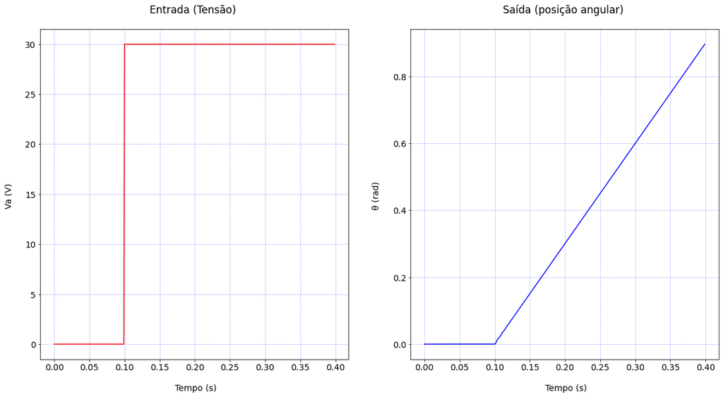

```python
fig, axes = plt.subplots(nrows=1, ncols=2, figsize=(20,10))

axes[0].plot(t,       Va,    color='r')
axes[1].plot(t_theta, theta, color='b')

axes[0].set_title('Entrada (Tensão) \n')
axes[1].set_title('Saída (posição angular) \n')

axes[0].set_xlabel('\n Tempo (s)')
axes[1].set_xlabel('\n Tempo (s)')

axes[0].set_ylabel('Va (V) \n')
axes[1].set_ylabel('θ (rad) \n')

axes[0].grid(color = 'b', alpha = 0.5, linestyle = 'dashed', linewidth = 0.5)
axes[1].grid(color = 'b', alpha = 0.5, linestyle = 'dashed', linewidth = 0.5)
```

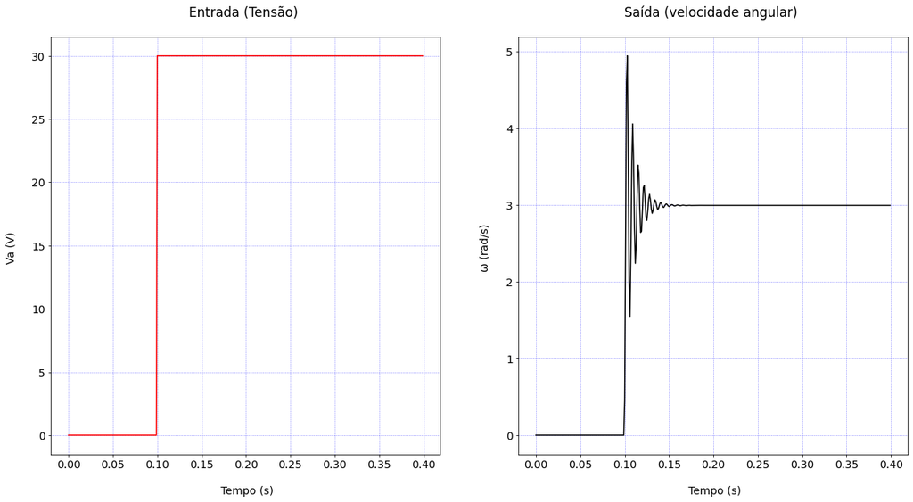

```python
fig, axes = plt.subplots(nrows=1, ncols=2, figsize=(20,10))

axes[0].plot(t,       Va,    color='r')
axes[1].plot(t_omega, omega, color='black')

axes[0].set_title('Entrada (Tensão) \n')
axes[1].set_title('Saída (velocidade angular) \n')

axes[0].set_xlabel('\n Tempo (s)')
axes[1].set_xlabel('\n Tempo (s)')

axes[0].set_ylabel('Va (V) \n')
axes[1].set_ylabel('ω (rad/s) \n')

axes[0].grid(color = 'b', alpha = 0.5, linestyle = 'dashed', linewidth = 0.5)
axes[1].grid(color = 'b', alpha = 0.5, linestyle = 'dashed', linewidth = 0.5)
```

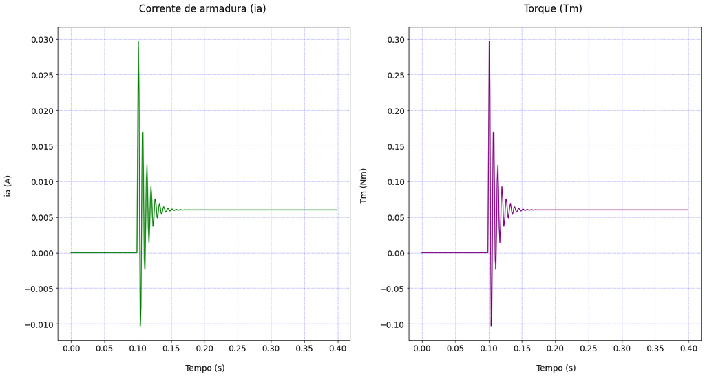

```python
fig, axes = plt.subplots(nrows=1, ncols=2, figsize=(20,10))

axes[0].plot(t_corrente, corrente, color='green')
axes[1].plot(t_Tm,       Tm,       color='purple')

axes[0].set_title('Corrente de armadura (ia) \n')
axes[1].set_title('Torque (Tm) \n')

axes[0].set_xlabel('\n Tempo (s)')
axes[1].set_xlabel('\n Tempo (s)')

axes[0].set_ylabel('ia (A) \n')
axes[1].set_ylabel('Tm (Nm) \n')

axes[0].grid(color = 'b', alpha = 0.5, linestyle = 'dashed', linewidth = 0.5)
axes[1].grid(color = 'b', alpha = 0.5, linestyle = 'dashed', linewidth = 0.5)
```